# Global Temperature Detrending vs Differencing

Bartosz Wędziński

04-02-2026

# 1 Wprowadzenie

## 1.1 Cel analizy

Celem niniejszego sprawozdania jest przeprowadzenie kompleksowej analizy szeregu czasowego `gtemp_both` reprezentującego odchylenia średniej rocznej temperatury globalnej (mierzonej na powierzchni lądów i oceanów) w latach 1850-2023 względem średniej temperatury dla okresu referencyjnego 1991-2020. Analiza koncentruje się na:

1. Identyfikacji i dopasowaniu optymalnych modeli autoregresyjnych AR(p) do danych.
2. Porównaniu dwóch alternatywnych podejść do osiągnięcia stacjonarności szeregu: różnicowania oraz eliminacji trendu wielomianowego.
3. Weryfikacji jakości dopasowanych modeli poprzez szczegółową diagnostykę reszt.
4. Konstrukcji prognoz temperatury globalnej na kolejne okresy z wykorzystaniem dopasowanych modeli.

## 1.2 Opis danych

Dane `gtemp_both` pochodzą z pakietu R `astsa` i zawierają 174 obserwacje roczne z lat 1850-2023. Szereg ten stanowi kluczowy wskaźnik zmian klimatycznych, pokazując długoterminowe trendy w globalnym ociepleniu. Wartości dodatnie wskazują na temperatury wyższe od średniej referencyjnej, podczas gdy wartości ujemne oznaczają temperatury niższe.

## 1.3 Przegląd metod

W analizie wykorzystano następujące metody statystyczne:

- **Testy stacjonarności**: Rozszerzony Test Dickey’a-Fullera (ADF) oraz test KPSS do oceny stacjonarności szeregu.
- **Transformacje stabilizujące**: Różnicowanie rzędu d oraz eliminacja trendu wielomianowego w celu uzyskania stacjonarności.
- **Identyfikacja modelu**: Funkcja częściowej autokorelacji (PACF) oraz kryteria informacyjne AIC i FPE do wyboru optymalnego rzędu p.
- **Estymacja parametrów**: Metoda Yule’a-Walkera (estymacja wstępna) oraz metoda największej wiarogodności (MLE).
- **Diagnostyka**: Testy białoszumowości (Ljung-Box, test graficzny), testy normalności reszt (Shapiro-Wilk, Jarque-Bera).
- **Prognozowanie**: Konstrukcja prognoz punktowych i przedziałowych z uwzględnieniem odwrócenia transformacji wstępnych.

# 2 Analiza wstępna i eksploracja danych

## 2.1 Charakterystyka szeregu

Szereg `gtemp_both` zawiera 174 obserwacji z lat 1850 do 2023.

Tabela 1: Statystyki opisowe szeregu gtemp both

| Statystyka | Wartość |
| --- | --- |
| Minimum | -0.6400 |
| Q1 | -0.2100 |
| Mediana | -0.0650 |
| Średnia | 0.0632 |
| Q3 | 0.2650 |
| Maksimum | 1.3500 |
| Odchylenie std. | 0.4020 |
| Wariancja | 0.1616 |

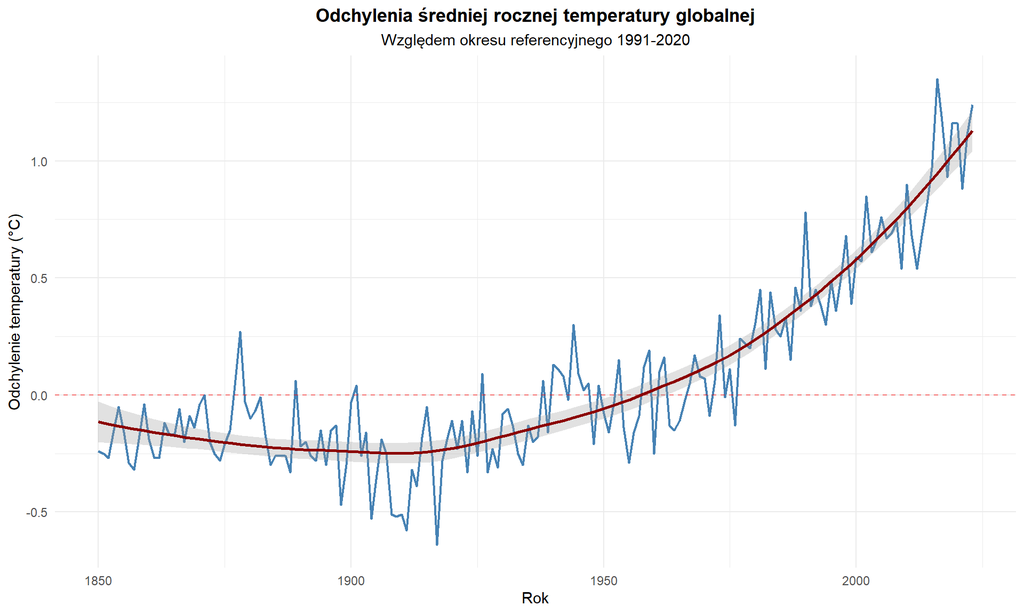

Rysunek 1: Szereg czasowy gtemp both - odchylenia średniej temperatury globalnej (1850-2023)

**Interpretacja**: Szereg wykazuje wyraźny trend wzrostowy, szczególnie intensywny od lat 70. XX wieku. Obserwujemy stopniowe ocieplanie się klimatu, z przyspieszeniem w ostatnich dekadach. Wartości oscylują wokół trendu, sugerując możliwość modelowania autoregresyjnego po eliminacji trendu lub zastosowaniu różnicowania.

## 2.2 Badanie stacjonarności

Przed dopasowaniem modeli autoregresyjnych należy zbadać stacjonarność szeregu. Stosujemy dwa komplementarne testy:

1. **Test ADF (Augmented Dickey-Fuller)**: H₀: szereg zawiera pierwiastek jednostkowy (niestacjonarny).
2. **Test KPSS (Kwiatkowski-Phillips-Schmidt-Shin)**: H₀: szereg jest stacjonarny wokół stałej lub trendu.

Tabela 2: Testy stacjonarności dla szeregu oryginalnego gtemp both

|  | Test | Statystyka | p-value | Wniosek ($\alpha$=0.05) |
| --- | --- | --- | --- | --- |
| Dickey-Fuller | ADF | -0.7927983 | 0.9604406 | Nie odrzucamy H0 (niestacjonarny) |
| KPSS Level | KPSS | 2.5929241 | 0.0100000 | Odrzucamy H0 (niestacjonarny) |

**Interpretacja wyników**:

- **Test ADF**: Nie odrzucamy H₀ (p ≥ 0.05), co wskazuje na obecność pierwiastka jednostkowego i niestacjonarność szeregu.
- **Test KPSS**: Odrzucamy H₀ (p < 0.05), co potwierdza niestacjonarność szeregu.

**Wniosek ogólny**: Szereg wykazuje silną niestacjonarność. W dalszej części analizy zweryfikujemy, czy ma ona charakter deterministyczny (poprzez eliminację trendu wielomianowego), czy stochastyczny (poprzez różnicowanie)

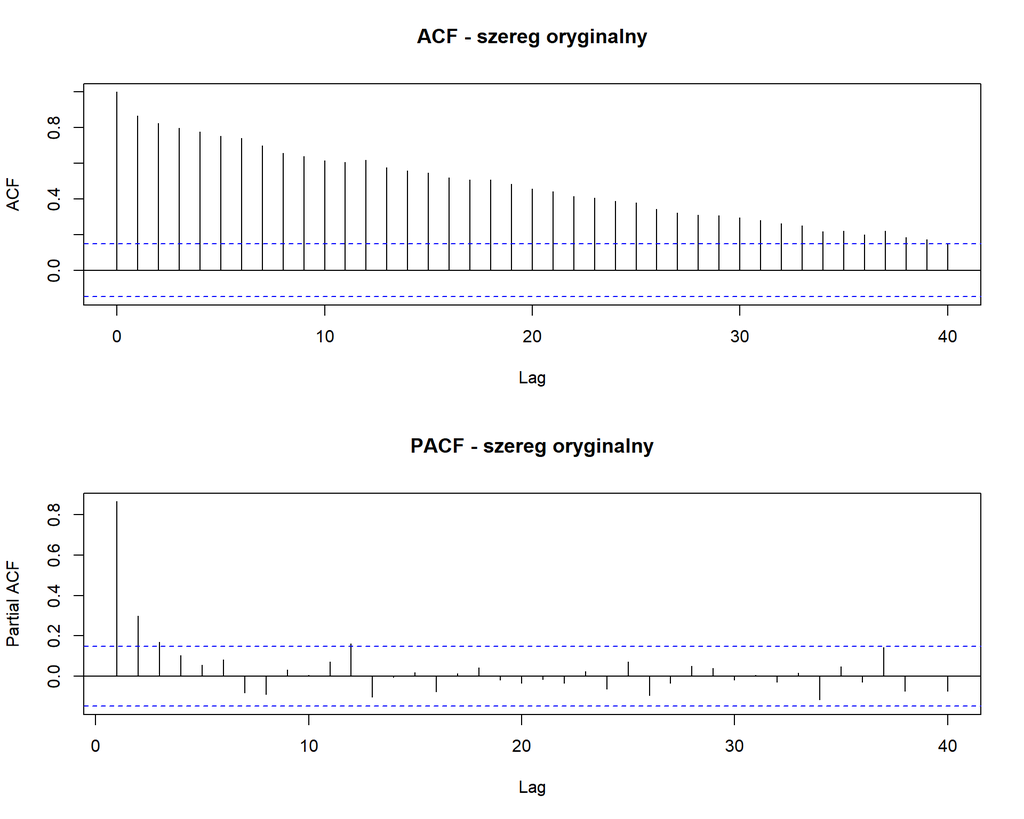

Rysunek 2: ACF i PACF dla szeregu oryginalnego

**Interpretacja ACF/PACF**: ACF wykazuje powolne zanikanie, charakterystyczne dla szeregów z trendem lub pierwiastkiem jednostkowym. PACF pokazuje istotne wartości dla pierwszych opóźnień, co potwierdza potrzebę transformacji przed modelowaniem.

# 3 Transformacje stabilizujące

Aby uzyskać stacjonarność szeregu, rozważamy dwa alternatywne podejścia:

1. **Podejście I**: Różnicowanie rzędu d
2. **Podejście II**: Eliminacja trendu wielomianowego

## 3.1 Podejście I: Różnicowanie

Różnicowanie jest klasyczną metodą eliminacji trendu w szeregach czasowych. Stosujemy różnicowanie pierwszego rzędu:

$$\nabla X_t = X_t - X_{t-1}$$

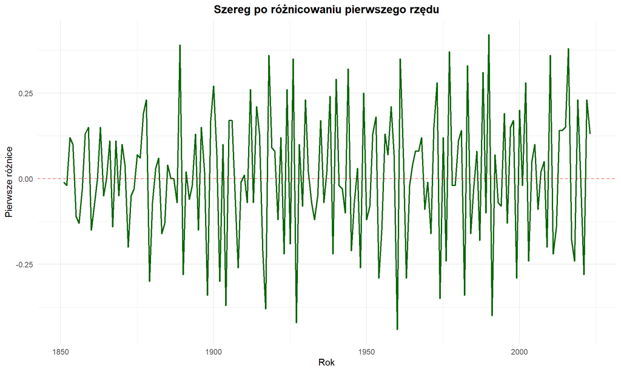

Rysunek 3: Szereg po różnicowaniu pierwszego rzędu

**Interpretacja**: Szereg po różnicowaniu oscyluje wokół stałej wartości, bez wyraźnego trendu. Wygląda na stacjonarny.

### 3.1.1 Testy stacjonarności po różnicowaniu

Tabela 3: Testy stacjonarności dla szeregu po różnicowaniu

|  | Test | Statystyka | p-value | Wniosek ($\alpha$=0.05) |
| --- | --- | --- | --- | --- |
| Dickey-Fuller | ADF | -8.1592968 | 0.01 | Odrzucamy H0 (stacjonarny) |
| KPSS Level | KPSS | 0.1727794 | 0.10 | Nie odrzucamy H0 (stacjonarny) |

**Interpretacja**:

- **Test ADF**: Odrzucamy H₀ (p < 0.05), co potwierdza stacjonarność szeregu po różnicowaniu.
- **Test KPSS**: Brak podstaw do odrzucenia hipotezy o stacjonarności H₀ (p ≥ 0.05).

**Wniosek**: Różnicowanie pierwszego rzędu skutecznie eliminuje trend, dając szereg, który można uznać za stacjonarny w świetle testu ADF.

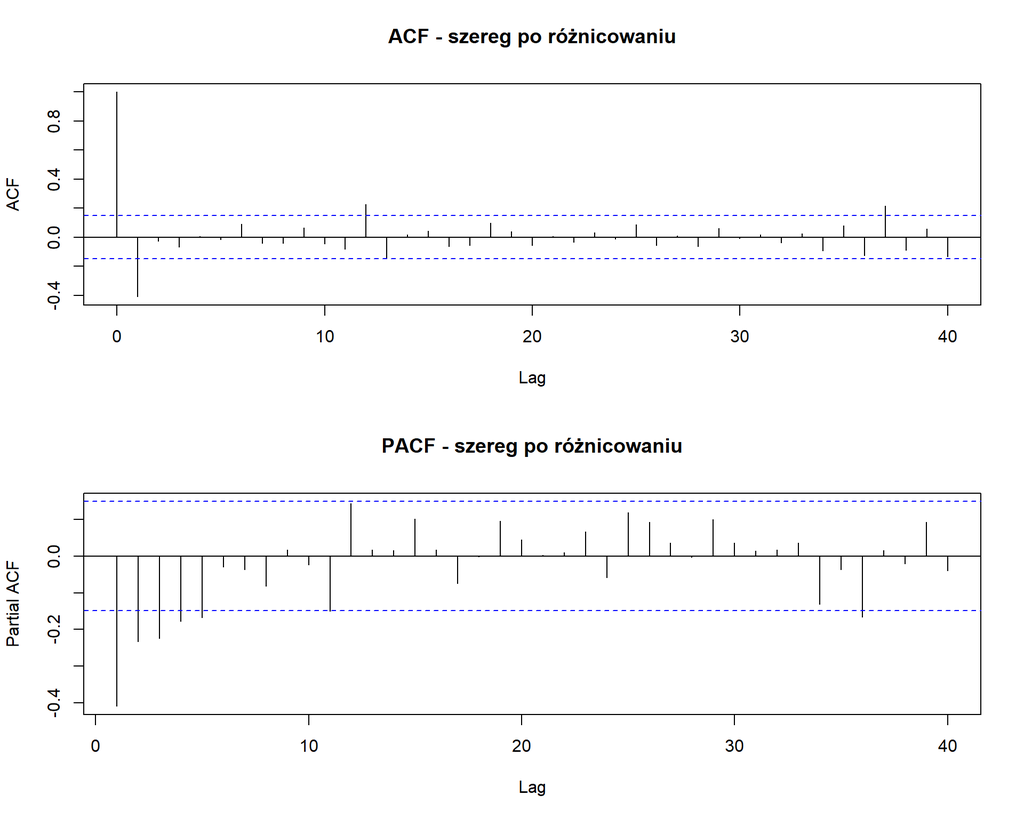

Rysunek 4: ACF i PACF dla szeregu po różnicowaniu

**Interpretacja ACF/PACF**: ACF szybko zanika do wartości nieistotnych, co jest charakterystyczne dla szeregów stacjonarnych. PACF pokazuje kilka istotnych opóźnień (szczególnie lag 1), co sugeruje model AR niskiego rzędu.

## 3.2 Podejście II: Eliminacja trendu wielomianowego

Alternatywnym podejściem jest estymacja i eliminacja trendu deterministycznego poprzez dopasowanie wielomianu odpowiedniego stopnia.

### 3.2.1 Wybór stopnia wielomianu

Dopasowujemy wielomiany różnych stopni (od 1 do 5) i porównujemy kryteria AIC oraz wizualnie oceniamy jakość dopasowania.

Tabela 4: Porównanie kryterium AIC dla wielomianów różnych stopni

| Stopień | AIC | Δ.AIC |
| --- | --- | --- |
| 1 | 20.49 | 176.85 |
| 2 | -140.90 | 15.46 |
| 3 | -153.31 | 3.05 |
| 4 | -151.39 | 4.97 |
| 5 | -156.36 | 0.00 |

**Interpretacja**: Najmniejszą wartość AIC uzyskano dla wielomianu stopnia 5, co sugeruje najlepsze dopasowanie przy uwzględnieniu kary za dodatkowe parametry. Jednakże, dla celów interpretacyjności i uniknięcia przeuczenia, rozważymy również wielomiany niższych stopni.

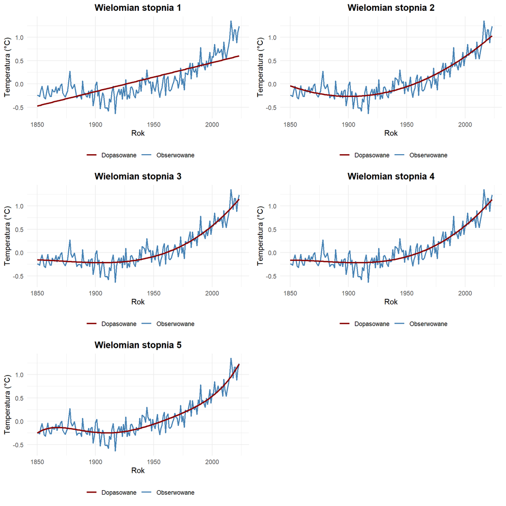

Rysunek 5: Porównanie dopasowania wielomianów różnych stopni

**Interpretacja wizualna**: Wielomian stopnia zaledwie 2 (paraboliczny) już dobrze oddaje ogólny trend wzrostowy z przyspieszeniem. Wielomiany wyższych stopni mogą prowadzić do przeuczenia i nierealistycznych ekstrapolacji, zwłaszcza dla zaledwie 174 obserwacji. Należy zachować ostrożność przy prognozowaniu, gdyż wielomiany wysokiego stopnia wykazują tendencję do niestabilności na krańcach szeregu.

### 3.2.2 Wybór ostateczny i eliminacja trendu

Dla celów badawczych odstępuję od zasady parsymonii i wybieram **wielomian stopnia 5**, mając jednocześnie świadomość istnienia ryzyka związanego z potencjalnym wyborem zbyt dużego stopnia.

**Oczekiwany rezultat:** Modelowanie temperatury globalnej wielomianem rzędu 5 doprowadzi do overfittingu, a w rezultacie tego doszłoby do absurdalnych prognoz za 20-30 lat (potencjalna niestabilność modelu zostanie ograniczona przez krótki horyzont prognozy (10 lat)).

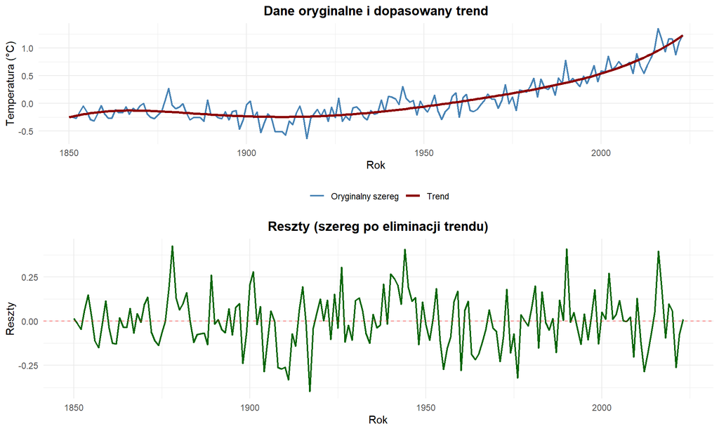

Rysunek 6: Szereg oryginalny, trend wielomianowy (stopień 5) oraz reszty

**Interpretacja**: Reszty oscylują wokół zera bez wyraźnego trendu, co sugeruje skuteczną eliminację trendu wielomianowego.

### 3.2.3 Testy stacjonarności reszt

Tabela 5: Testy stacjonarności dla szeregu po eliminacji trendu

|  | Test | Statystyka | p-value | Wniosek ($\alpha$=0.05) |
| --- | --- | --- | --- | --- |
| Dickey-Fuller | ADF | -4.4464747 | 0.01 | Odrzucamy H0 (stacjonarny) |
| KPSS Level | KPSS | 0.0497199 | 0.10 | Nie odrzucamy H0 (stacjonarny) |

**Interpretacja**:

- **Test ADF**: Odrzucamy H₀ (p < 0.05), potwierdzając stacjonarność reszt.
- **Test KPSS**: Brak podstaw do odrzucenia hipotezy o stacjonarności H₀ (p ≥ 0.05).

**Wniosek**: Eliminacja trendu wielomianowego skutecznie prowadzi do stacjonarnego szeregu reszt, zgodnie z testem ADF.

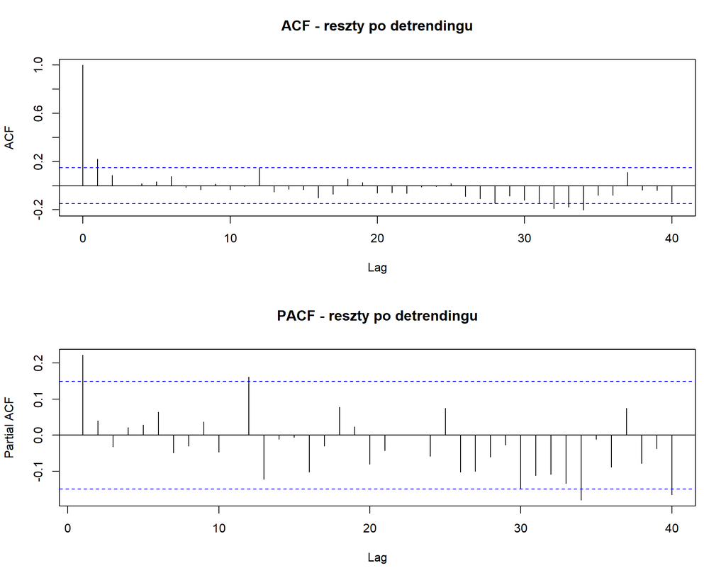

Rysunek 7: ACF i PACF dla szeregu po eliminacji trendu

**Interpretacja ACF/PACF**: ACF szybko maleje, potwierdzając stacjonarność. PACF pokazuje istotne wartości dla pierwszego lagu, sugerując model AR bardzo niskiego rzędu (1).

## 3.3 Porównanie obu podejść

Tabela 6: Porównanie wyników testów stacjonarności dla obu metod transformacji

| Metoda | Test | Statystyka | p-value | Wniosek |
| --- | --- | --- | --- | --- |
| **Różnicowanie** |  |  |  |  |
| Różnicowanie (d=1) | ADF | -8.1592968 | 0.01 | Odrzucamy H0 (stacjonarny) |
| Różnicowanie (d=1) | KPSS | 0.1727794 | 0.10 | Nie odrzucamy H0 (stacjonarny) |
| **Eliminacja trendu (stopień 5)** |  |  |  |  |
| Eliminacja trendu (stopień = 5) | ADF | -4.4464747 | 0.01 | Odrzucamy H0 (stacjonarny) |
| Eliminacja trendu (stopień = 5) | KPSS | 0.0497199 | 0.10 | Nie odrzucamy H0 (stacjonarny) |

**Wnioski porównawcze**:

- Różnicowanie wprowadziło silną ujemną autokorelację pierwszego rzędu (ok. -0.4) - to ważny sygnał diagnostyczny, który oznacza, że szereg pierwotny mógł zostać przeróżnicowany oraz, że mógł mieć charakter trend-stacjonarny. Reszty po eliminacji trendu zachowują dodatnią autokorelację (ok. 0.2 dla 1. lagu). Sugeruje to inną strukturę modelu AR(p) dla obu podejść
- Oba podejścia skutecznie eliminują trend i prowadzą do szeregów, które można uznać za stacjonarne w świetle testu ADF.
- Test KPSS jest bardziej konserwatywny i może wskazywać na odrzucenie H₀ nawet przy niewielkich odchyleniach od idealnej stacjonarności.
- **Różnicowanie** jest prostsze obliczeniowo i nie wymaga dodatkowych założeń o kształcie trendu.
- **Eliminacja trendu wielomianowego** pozwala na bezpośrednią interpretację trendu i może być preferowana, gdy trend ma jasną interpretację fizyczną.

W dalszej części analizy dopasujemy modele AR(p) do obu przetransformowanych szeregów i porównamy ich jakość oraz użyteczność prognostyczną.

# 4 Identyfikacja rzędu modelu AR(p)

Dla obu podejść (różnicowanie i eliminacja trendu) przeprowadzimy identyfikację optymalnego rzędu p modelu autoregresyjnego AR(p) za pomocą:

1. **Analizy PACF** (metoda graficzna)
2. **Kryteriów informacyjnych AIC i FPE** (metoda analityczna)

## 4.1 Metoda graficzna: PACF

Funkcja częściowej autokorelacji (PACF) pozwala zidentyfikować rząd p poprzez obserwację, przy którym opóźnieniu wartości PACF stają się nieistotne statystycznie.

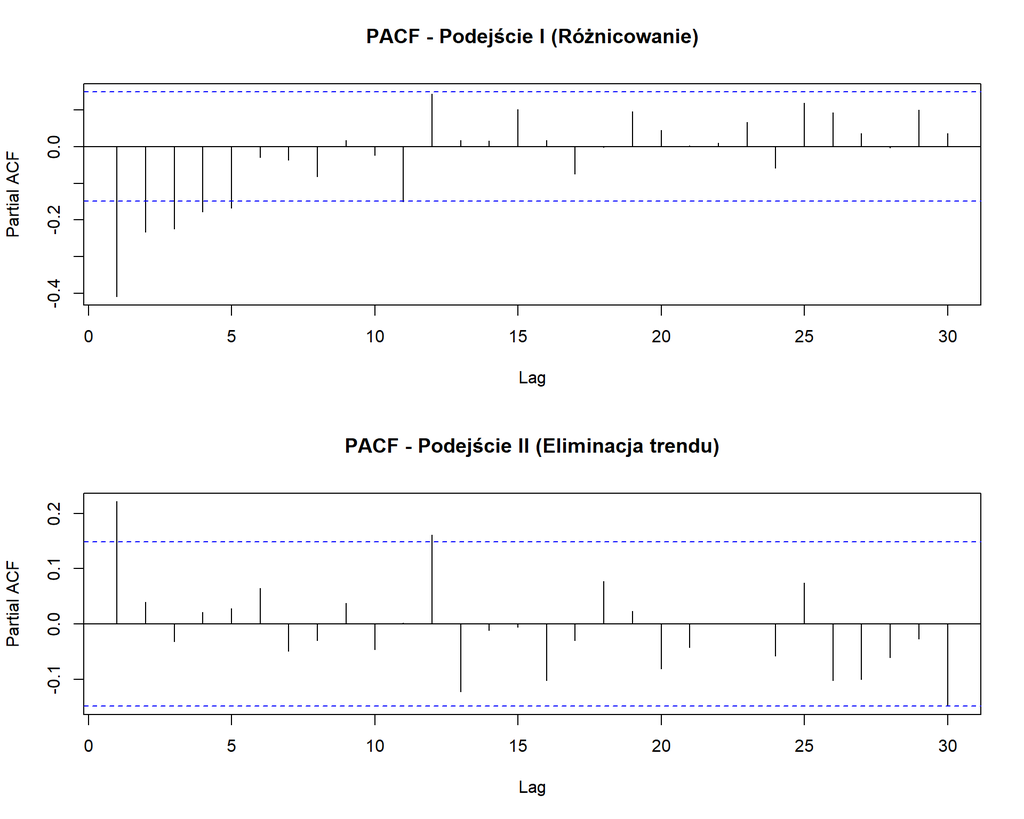

Rysunek 8: PACF dla obu podejść transformacji

**Interpretacja**:

- **Podejście I (Różnicowanie)**: PACF pokazuje istotne wartości dla opóźnień 1, 2, 3, 4 oraz 5, co sugeruje model **AR(5)**.
- **Podejście II (Eliminacja trendu)**: PACF wskazuje na istotną wartośc dla pierwszego opóźnienia, sugerując niższy rząd modelu **AR(1)**.

Wstępnie rozważamy modele AR(p) dla p ∈ {1, 5}.

## 4.2 Kryteria informacyjne: AIC i FPE

Dla bardziej obiektywnej identyfikacji rzędu p, obliczamy kryteria AIC (Akaike Information Criterion) i FPE (Final Prediction Error) dla zakresu p ∈ {0, 1, 2, …, 20}.

### 4.2.1 Podejście I: Różnicowanie

Tabela 7: Top 10 wartości AIC i FPE dla modeli AR(p) - Podejście I (Różnicowanie)

| p | AIC | FPE |
| --- | --- | --- |
| 5 | -138.3323 | 0.0256 |
| 6 | -136.4635 | 0.0259 |
| 4 | -135.1932 | 0.0261 |
| 7 | -134.6008 | 0.0262 |
| 12 | -134.1287 | 0.0261 |
| 8 | -133.7987 | 0.0263 |
| 11 | -133.4909 | 0.0263 |
| 13 | -132.2067 | 0.0264 |
| 9 | -131.8278 | 0.0266 |
| 3 | -131.6749 | 0.0267 |

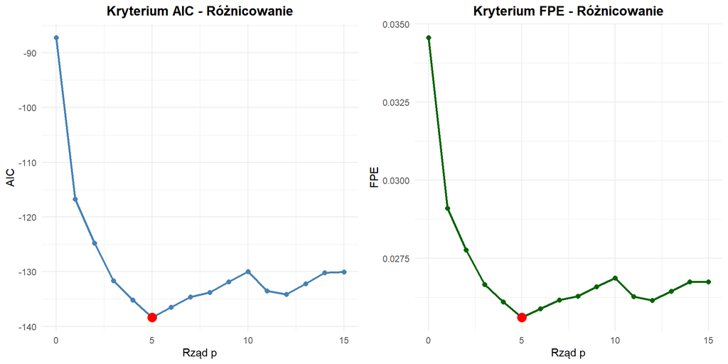

Rysunek 9: Kryteria AIC i FPE w funkcji rzędu p - Podejście I (Różnicowanie)

**Interpretacja**:

- **AIC**: Minimalne AIC osiągnięto dla p = **5**, co sugeruje model **AR(5)**.
- **FPE**: Minimalne FPE dla p = **5**.

**Wniosek**: Kryteria informacyjne wskazują jednoznacznie na model AR(5) jako optymalny dla szeregu po różnicowaniu.

### 4.2.2 Podejście II: Eliminacja trendu

Tabela 8: Top 10 wartości AIC i FPE dla modeli AR(p) - Podejście II (Eliminacja trendu)

| p | AIC | FPE |
| --- | --- | --- |
| 1 | -173.0547 | 0.0212 |
| 2 | -171.3234 | 0.0214 |
| 3 | -169.4995 | 0.0216 |
| 4 | -167.5826 | 0.0218 |
| 0 | -166.3580 | 0.0220 |
| 5 | -165.7278 | 0.0221 |
| 6 | -164.4364 | 0.0222 |
| 7 | -162.8661 | 0.0224 |
| 8 | -161.0448 | 0.0227 |
| 9 | -159.3242 | 0.0229 |

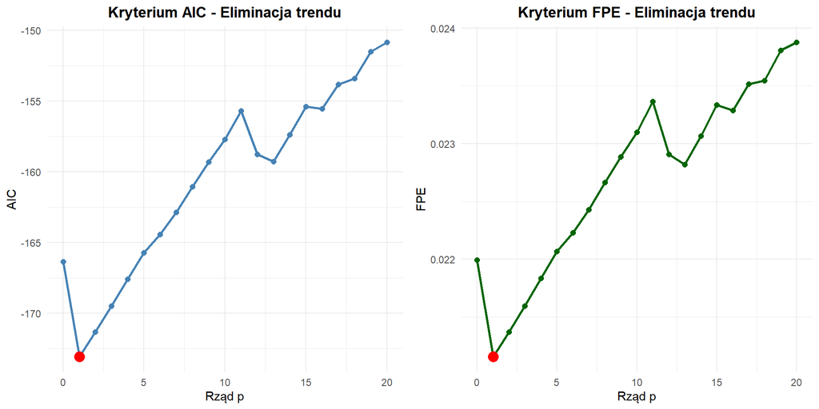

Rysunek 10: Kryteria AIC i FPE w funkcji rzędu p - Podejście II (Eliminacja trendu)

**Interpretacja**:

- **AIC**: Minimalne AIC dla p = **1**.
- **FPE**: Minimalne FPE dla p = **1**.

**Wniosek**: Kryteria informacyjne wskazują jednoznacznie na model AR(1) jako optymalny dla szeregu po eliminacji trendu.

## 4.3 Porównanie identyfikacji dla obu podejść

Tabela 9: Porównanie optymalnych rzędów p dla obu podejść

| Metoda | Optymalny rząd p (AIC) | Min AIC | Min FPE |
| --- | --- | --- | --- |
| Różnicowanie | 5 | -138.3323 | 0.0256 |
| Eliminacja trendu | 1 | -173.0547 | 0.0212 |

**Wnioski**:

- Dla szeregu po eliminacji trendu wielomianowego, struktura reszt jest prosta i najlepiej opisuje ją model AR(1). Oznacza to, że po odjęciu trendu deterministycznego, odchylenia temperatury mają charakter krótko-pamięciowy (proces Markowa).
- Dla szeregu różnicowanego, kryteria wskazują na bardziej złożony model AR(5). Jest to częste zjawisko – różnicowanie skutecznie usuwa trend stochastyczny, ale może wprowadzać bardziej skomplikowane korelacje w krótkim okresie, wymagające dłuższego rzędu modelu do “wybielenia” szumu.
- Warto zauważyć, że o ile model dla eliminacji trendu osiągnął niższą wartość AIC (-173.05) niż model dla różnicowania (-138.33), to nie można wyciągnąć wniosku, że jest lepiej dopasowany, ze względu na niemożność porównywania kryteriów informacyjnych dla różnych zmiennych objaśnianych.
- W dalszej części dopasujemy modele AR(5) dla różnicowania oraz AR(1) dla eliminacji trendu.

# 5 Estymacja parametrów modeli AR(p)

Dla zidentyfikowanych modeli przeprowadzimy estymację parametrów dwiema metodami:

1. **Metoda Yule’a-Walkera** (YW) - estymacja wstępna oparta na autokorelacjach.
2. **Metoda największej wiarogodności** (MLE) - estymacja maksymalizująca funkcję wiarogodności.

## 5.1 Podejście I: Różnicowanie

### 5.1.1 Model AR(5) - Metoda Yule’a-Walkera

Tabela 10: Parametry modelu AR(5) - Metoda Yule’a-Walkera (Różnicowanie)

| Parametr | Estymator | Błąd std. |
| --- | --- | --- |
| φ_1 | -0.6267 | 0.0763 |
| φ_2 | -0.4626 | 0.0878 |
| φ_3 | -0.3922 | 0.0898 |
| φ_4 | -0.2780 | 0.0878 |
| φ_5 | -0.1678 | 0.0763 |

**Wariancja reszt**: σ² = 0.025192

### 5.1.2 Model AR(5) - Metoda MLE

Tabela 11: Parametry modelu AR(5) - Metoda MLE (Różnicowanie)

|  | Parametr | Estymator | Błąd std. |
| --- | --- | --- | --- |
| ar1 | φ_1 | -0.6312 | 0.0747 |
| ar2 | φ_2 | -0.4699 | 0.0860 |
| ar3 | φ_3 | -0.3940 | 0.0880 |
| ar4 | φ_4 | -0.2812 | 0.0860 |
| ar5 | φ_5 | -0.1719 | 0.0747 |

**Wariancja reszt**: σ² = 0.02417

### 5.1.3 Porównanie metod YW i MLE

Tabela 12: Porównanie metod YW i MLE - Podejście I (Różnicowanie)

|  | Parametr | YW - Estymator | YW - SE | MLE - Estymator | MLE - SE | Różnica estymat. |
| --- | --- | --- | --- | --- | --- | --- |
| ar1 | φ_1 | -0.6267 | 0.0763 | -0.6312 | 0.0747 | 0.0045 |
| ar2 | φ_2 | -0.4626 | 0.0878 | -0.4699 | 0.0860 | 0.0073 |
| ar3 | φ_3 | -0.3922 | 0.0898 | -0.3940 | 0.0880 | 0.0018 |
| ar4 | φ_4 | -0.2780 | 0.0878 | -0.2812 | 0.0860 | 0.0032 |
| ar5 | φ_5 | -0.1678 | 0.0763 | -0.1719 | 0.0747 | 0.0041 |

**Interpretacja**:

- Estymatory uzyskane metodami YW i MLE są **bardzo zbliżone**, co potwierdza zbieżność obu metod dla tego szeregu.
- Błędy standardowe są również podobne, przy czym MLE może dać nieznacznie dokładniejsze oszacowania dla małych prób.
- **Wariancja reszt** jest niemal identyczna dla obu metod.

**Wniosek**: Ze względu na teoretyczną efektywność, w dalszej analizie będziemy korzystać z **metody MLE**.

## 5.2 Podejście II: Eliminacja trendu

### 5.2.1 Model AR(1) - Metoda Yule’a-Walkera

Tabela 13: Parametry modelu AR(1) - Metoda Yule’a-Walkera (Eliminacja trendu)

| Parametr | Estymator | Błąd std. |
| --- | --- | --- |
| φ_1 | 0.2214 | 0.0744 |

**Wariancja reszt**: σ² = 0.02116

### 5.2.2 Model AR(1) - Metoda MLE

Tabela 14: Parametry modelu AR(1) - Metoda MLE (Eliminacja trendu)

|  | Parametr | Estymator | Błąd std. |
| --- | --- | --- | --- |
| ar1 | φ_1 | 0.2202 | 0.0739 |

**Wariancja reszt**: σ² = 0.020917

### 5.2.3 Porównanie metod YW i MLE

Tabela 15: Porównanie metod YW i MLE - Podejście II (Eliminacja trendu)

|  | Parametr | YW - Estymator | YW - SE | MLE - Estymator | MLE - SE | Różnica estymat. |
| --- | --- | --- | --- | --- | --- | --- |
| ar1 | φ_1 | 0.2214 | 0.0744 | 0.2202 | 0.0739 | 0.0012 |

**Interpretacja**: Analogicznie jak w Podejściu I, estymatory są bardzo zbliżone, potwierdzając spójność obu metod.

# 6 Asymptotyczne przedziały ufności i weryfikacja istotności parametrów

Opierając się na **twierdzeniu o asymptotycznej normalności estymatorów MLE**, konstruujemy 95% przedziały ufności dla parametrów modeli AR(p) i weryfikujemy ich statystyczną istotność.

## 6.1 Podejście I: Różnicowanie

Tabela 16: Asymptotyczne przedziały ufności (95%) dla parametrów modelu AR(5) - Różnicowanie

|  | Parametr | Estymator | SE | 95% CI - Dolna | 95% CI - Górna | p-value | Istotny (α=0.05) |
| --- | --- | --- | --- | --- | --- | --- | --- |
| ar1 | φ_1 | -0.6312 | 0.0747 | -0.7776 | -0.4847 | 0.0000 | Tak |
| ar2 | φ_2 | -0.4699 | 0.0860 | -0.6384 | -0.3013 | 0.0000 | Tak |
| ar3 | φ_3 | -0.3940 | 0.0880 | -0.5664 | -0.2215 | 0.0000 | Tak |
| ar4 | φ_4 | -0.2812 | 0.0860 | -0.4498 | -0.1127 | 0.0011 | Tak |
| ar5 | φ_5 | -0.1719 | 0.0747 | -0.3184 | -0.0255 | 0.0214 | Tak |

**Interpretacja**:

- **Parametry istotne statystycznie**: φ_1, φ_2, φ_3, φ_4, φ_5

**Wniosek**: Wszystkie parametry modelu AR(5) są istotne statystycznie, potwierdzając trafność wyboru rzędu p.

## 6.2 Podejście II: Eliminacja trendu

Tabela 17: Asymptotyczne przedziały ufności (95%) dla parametrów modelu AR(1) - Eliminacja trendu

|  | Parametr | Estymator | SE | 95% CI - Dolna | 95% CI - Górna | p-value | Istotny (α=0.05) |
| --- | --- | --- | --- | --- | --- | --- | --- |
| ar1 | φ_1 | 0.2202 | 0.0739 | 0.0753 | 0.3651 | 0.0029 | Tak |

**Interpretacja**:

- **Parametry istotne statystycznie**: φ_1

**Wniosek**: Wszystkie parametry są istotne, potwierdzając adekwatność modelu AR(1).

# 7 Diagnostyka modeli - Analiza reszt

Kluczowym etapem weryfikacji poprawności dopasowania modeli AR(p) jest analiza reszt. Reszty powinny być **białym szumem**, tzn. nieskorelowane, o stałej wariancji i rozkładzie normalnym.

## 7.1 Podejście I: Różnicowanie

### 7.1.1 Wykresy diagnostyczne

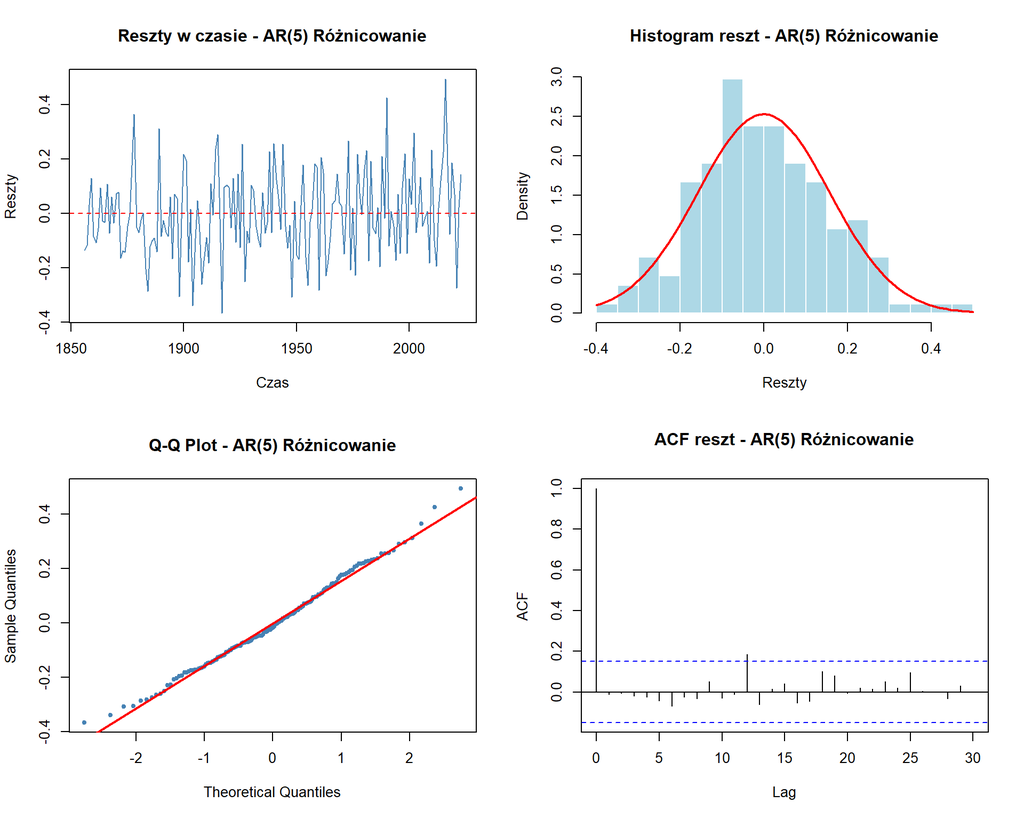

Rysunek 11: Diagnostyka reszt modelu AR(5) - Różnicowanie

### 7.1.2 Testy białoszumowości

Tabela 18: Test Ljung-Box dla reszt modelu AR(5) - Różnicowanie

|  | Lag | Statystyka | p-value | Decyzja |
| --- | --- | --- | --- | --- |
| X-squared | 5 | 0.4950 | 0.9923 | Nie odrzucamy H0 (biały szum) |
| X-squared1 | 10 | 2.2718 | 0.9938 | Nie odrzucamy H0 (biały szum) |
| X-squared2 | 15 | 9.6409 | 0.8417 | Nie odrzucamy H0 (biały szum) |
| X-squared3 | 20 | 13.7438 | 0.8432 | Nie odrzucamy H0 (biały szum) |

Tabela 19: Test graficzny (ACF) dla reszt modelu AR(5) - Różnicowanie

| Test | Częstość przekroczeń | Ekstrema (3$\sigma$) | Decyzja |
| --- | --- | --- | --- |
| Test graficzny (ACF) | 5% | Nie | Biały szum |

**Interpretacja testów białoszumowości**:

- **Test Ljung-Box**: Dla wszystkich rozważanych opóźnień nie odrzucamy H₀ (p ≥ 0.05), co potwierdza, że reszty są nieskorelowane (biały szum).
- **Test graficzny (ACF)**: Biały szum. Częstość przekroczeń przedziałów istotności wynosi 5%, co jest zgodne z oczekiwaniami dla białego szumu (około 5% dla α=0.05).

**Wniosek**: Reszty modelu AR(5) spełniają założenie białoszumowości, co potwierdza poprawność dopasowania modelu.

### 7.1.3 Testy normalności reszt

Tabela 20: Testy normalności reszt modelu AR(5) - Różnicowanie

|  | Test | Statystyka | p-value | Wniosek ($\alpha$=0.05) |
| --- | --- | --- | --- | --- |
| W | Shapiro-Wilk | 0.9921 | 0.4895 | Nie odrzucamy H0 (normalny) |
| X-squared | Jarque-Bera | 2.2565 | 0.3236 | Nie odrzucamy H0 (normalny) |

**Interpretacja testów normalności**:

- **Test Shapiro-Wilka**: Nie odrzucamy H₀ (p ≥ 0.05), potwierdzając normalność reszt.
- **Test Jarque-Bera**: Nie odrzucamy H₀ (p ≥ 0.05), potwierdzając normalność reszt.

**Wniosek**: Reszty można uznać za pochodzące z rozkładu normalnego, co spełnia założenia modelu AR.

## 7.2 Podejście II: Eliminacja trendu

### 7.2.1 Wykresy diagnostyczne

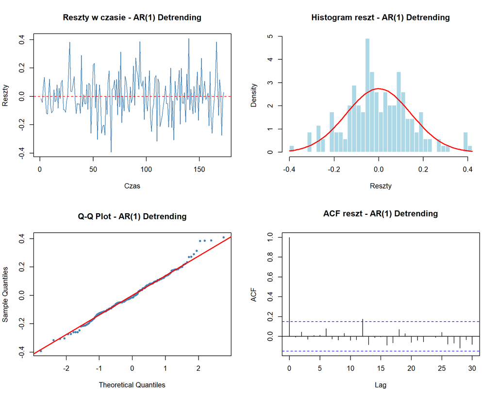

Rysunek 12: Diagnostyka reszt modelu AR(1) - Eliminacja trendu

### 7.2.2 Testy białoszumowości

Tabela 21: Test Ljung-Box dla reszt modelu AR(1) - Eliminacja trendu

|  | Lag | Statystyka | p-value | Decyzja |
| --- | --- | --- | --- | --- |
| X-squared | 5 | 0.5644 | 0.9896 | Nie odrzucamy H0 (biały szum) |
| X-squared1 | 10 | 2.5421 | 0.9902 | Nie odrzucamy H0 (biały szum) |
| X-squared2 | 15 | 9.8806 | 0.8272 | Nie odrzucamy H0 (biały szum) |
| X-squared3 | 20 | 14.0148 | 0.8297 | Nie odrzucamy H0 (biały szum) |

Tabela 22: Test graficzny (ACF) dla reszt modelu AR(1) - Eliminacja trendu

| Test | Częstość przekroczeń | Ekstrema (3$\sigma$) | Decyzja |
| --- | --- | --- | --- |
| Test graficzny (ACF) | 5% | Nie | Biały szum |

**Interpretacja**: Reszty spełniają założenie białoszumowości.

### 7.2.3 Testy normalności reszt

Tabela 23: Testy normalności reszt modelu AR(1) - Eliminacja trendu

|  | Test | Statystyka | p-value | Wniosek ($\alpha$=0.05) |
| --- | --- | --- | --- | --- |
| W | Shapiro-Wilk | 0.9915 | 0.3942 | Nie odrzucamy H0 (normalny) |
| X-squared | Jarque-Bera | 1.4150 | 0.4929 | Nie odrzucamy H0 (normalny) |

**Interpretacja**: Reszty są zgodne z rozkładem normalnym.

## 7.3 Porównanie diagnostyki dla obu podejść

Tabela 24: Podsumowanie diagnostyki reszt dla obu podejść

| Metoda | Test Ljung-Box (p > 0.05) | Test graficzny | Shapiro-Wilk (p > 0.05) | Jarque-Bera (p > 0.05) |
| --- | --- | --- | --- | --- |
| Różnicowanie | TRUE | Biały szum | TRUE | TRUE |
| Eliminacja trendu | TRUE | Biały szum | TRUE | TRUE |

**Wnioski porównawcze**:

- Oba podejścia prowadzą do modeli, których reszty spełniają założenia białoszumowości.
- Diagnostyka reszt nie wskazuje jednoznacznie na przewagę jednego podejścia nad drugim w zakresie jakości dopasowania.
- Ewentualne drobne odchylenia od idealnego białego szumu są akceptowalne w kontekście rzeczywistych danych klimatycznych.

# 8 Prognozowanie

Wykorzystujemy dopasowane modele AR(p) do konstrukcji prognoz temperatury globalnej na kolejne **10 lat** (h = 10). Kluczowe jest **odwrócenie transformacji wstępnych**, aby prognozy były wyrażone w skali oryginalnej.

## 8.1 Podejście I: Różnicowanie

### 8.1.1 Prognozy w skali różnicowanej

Tabela 25: Prognozy z modelu AR(5) - skala różnicowana (Różnicowanie)

| Okres | Prognoza | 95% PI - Dolna | 95% PI - Górna |
| --- | --- | --- | --- |
| 1 | -0.096265714 | -0.4009806 | 0.2084492 |
| 2 | 0.010891782 | -0.3494465 | 0.3712300 |
| 3 | -0.006309105 | -0.3673052 | 0.3546870 |
| 4 | -0.016214582 | -0.3775617 | 0.3451325 |
| 5 | 0.036722060 | -0.3247739 | 0.3982180 |
| 6 | 0.023503587 | -0.3381665 | 0.3851737 |
| 7 | -0.002709514 | -0.3659284 | 0.3605094 |
| 8 | 0.004934095 | -0.3589679 | 0.3688360 |
| 9 | 0.004451184 | -0.3595049 | 0.3684073 |
| 10 | 0.006108467 | -0.3578665 | 0.3700834 |

### 8.1.2 Odwrócenie transformacji (integracja)

Ponieważ zastosowaliśmy różnicowanie pierwszego rzędu, prognozy dotyczą **przyrostów** temperatury. Aby uzyskać prognozy w skali oryginalnej, musimy **zintegrować** różnice, zaczynając od ostatniej obserwowanej wartości szeregu oryginalnego.

Tabela 26: Prognozy z modelu AR(5) - skala oryginalna po integracji (Różnicowanie)

| Rok | Prognoza | 95% PI - Dolna | 95% PI - Górna |
| --- | --- | --- | --- |
| 2024 | 1.1437 | 0.8390 | 1.4484 |
| 2025 | 1.1546 | 0.4896 | 1.8197 |
| 2026 | 1.1483 | 0.1223 | 2.1744 |
| 2027 | 1.1321 | -0.2553 | 2.5195 |
| 2028 | 1.1688 | -0.5801 | 2.9177 |
| 2029 | 1.1923 | -0.9182 | 3.3029 |
| 2030 | 1.1896 | -1.2842 | 3.6634 |
| 2031 | 1.1946 | -1.6431 | 4.0322 |
| 2032 | 1.1990 | -2.0026 | 4.4006 |
| 2033 | 1.2051 | -2.3605 | 4.7707 |

### 8.1.3 Wizualizacja prognoz

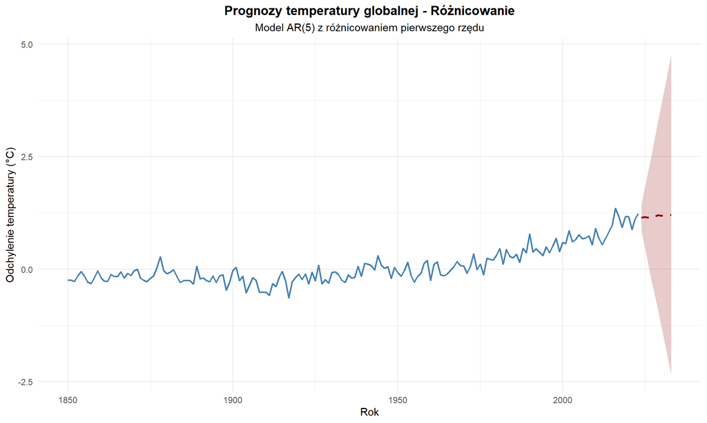

Rysunek 13: Prognozy temperatury globalnej - Podejście I (Różnicowanie)

## 8.2 Podejście II: Eliminacja trendu

### 8.2.1 Prognozy reszt (bez trendu)

Tabela 27: Prognozy reszt z modelu AR(1) - bez trendu (Eliminacja trendu)

| Okres | Prognoza reszt | 95% PI - Dolna | 95% PI - Górna |
| --- | --- | --- | --- |
| 1 | 2.700211e-03 | -0.2807661 | 0.2861665 |
| 2 | 5.947614e-04 | -0.2896606 | 0.2908501 |
| 3 | 1.312098e-04 | -0.2904492 | 0.2907116 |
| 4 | 2.915084e-05 | -0.2905670 | 0.2906253 |
| 5 | 6.680761e-06 | -0.2905902 | 0.2906036 |
| 6 | 1.733581e-06 | -0.2905952 | 0.2905987 |
| 7 | 6.443720e-07 | -0.2905963 | 0.2905976 |
| 8 | 4.045637e-07 | -0.2905966 | 0.2905974 |
| 9 | 3.517657e-07 | -0.2905966 | 0.2905973 |
| 10 | 3.401413e-07 | -0.2905966 | 0.2905973 |

### 8.2.2 Odwrócenie transformacji (dodanie trendu)

Aby uzyskać prognozy w skali oryginalnej, dodajemy z powrotem **prognozowany trend wielomianowy** dla przyszłych okresów.

Tabela 28: Prognozy z modelu AR(1) - skala oryginalna po dodaniu trendu (Eliminacja trendu)

| Rok | Prognoza | 95% PI - Dolna | 95% PI - Górna |
| --- | --- | --- | --- |
| 2024 | 1.275958 | 0.9590844 | 1.592832 |
| 2025 | 1.321136 | 0.9913941 | 1.650878 |
| 2026 | 1.369784 | 1.0317909 | 1.707777 |
| 2027 | 1.420689 | 1.0734094 | 1.767969 |
| 2028 | 1.473640 | 1.1156613 | 1.831618 |
| 2029 | 1.528644 | 1.1584318 | 1.898857 |
| 2030 | 1.585762 | 1.2016742 | 1.969851 |
| 2031 | 1.645066 | 1.2453617 | 2.044770 |
| 2032 | 1.706630 | 1.2894791 | 2.123781 |
| 2033 | 1.770533 | 1.3340215 | 2.207045 |

### 8.2.3 Wizualizacja prognoz

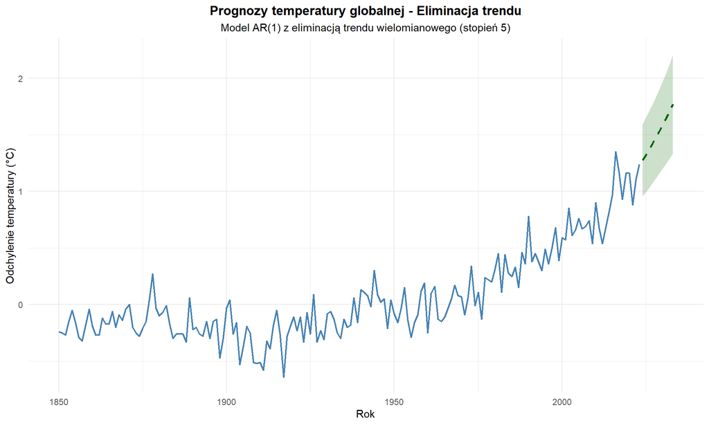

Rysunek 14: Prognozy temperatury globalnej - Podejście II (Eliminacja trendu)

**Interpretacja prognoz**:

- Prognozy z tego podejścia również wskazują na **wzrost temperatury**, zgodnie z ekstrapolacją trendu wielomianowego.
- W zależności od stopnia wielomianu, prognozy mogą wykazywać **przyspieszenie** (dla wielomianów wyższych stopni) lub bardziej **liniowy** wzrost.
- Przedziały predykcji są o wiele węższe, niż w Podejściu I.

## 8.3 Porównanie prognoz

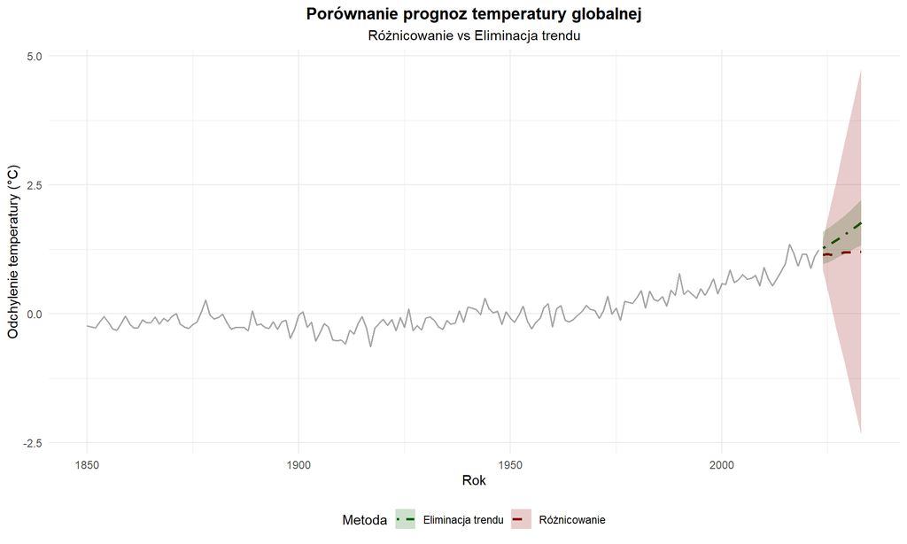

Rysunek 15: Porównanie prognoz z obu podejść modelowania

**Interpretacja porównania**:

- **Średnia prognoz (10 lat)**:
  - Różnicowanie: 1.1728 °C
  - Eliminacja trendu: 1.5098 °C

**Wnioski**:

Mimo uwzględnienia błędu estymacji trendu (SE fit), przedziały ufności dla metody detrendingu pozostają wąskie i stabilne (kształt tunelu). Wynika to z faktu, że model ten traktuje trend jako zjawisko deterministyczne (sztywne). Przy dużej próbie (174 lata) błąd dopasowania wielomianu jest znikomy w porównaniu do wariancji reszt.

Stoi to w jaskrawym kontraście do metody różnicowania (model stochastyczny), gdzie niepewność kumuluje się z każdym krokiem (“lejek”). Wąski tunel w metodzie detrendingu jest matematycznie poprawny przy przyjętych założeniach, ale może dawać złudne poczucie pewności co do przyszłości, ignorując możliwość zmiany strukturalnej trendu, której wielomian nie jest w stanie przewidzieć.

Wielomian 5. stopnia może w przyszłości “przestrzelić” rzeczywistość. Podejście różnicowe jest matematycznie bezpieczniejsze (nie narzuca kształtu przyszłości), ale w długim horyzoncie czasowym generuje tak dużą niepewność, że prognoza staje się mało informatywna dla decydentów.

# 9 Wnioski końcowe

## 9.1 Porównanie podejść modelowania

W niniejszym sprawozdaniu przeprowadzono kompleksową analizę szeregu czasowego `gtemp_both`, porównując dwa alternatywne podejścia do osiągnięcia stacjonarności i dopasowania modeli autoregresyjnych AR(p):

1. **Podejście I: Różnicowanie pierwszego rzędu**
2. **Podejście II: Eliminacja trendu wielomianowego (stopień 5)**

### 9.1.1 Mocne strony różnicowania

- **Prostota**: Łatwość implementacji i brak konieczności wyboru parametrów (stopnia wielomianu).
- **Brak założeń o postaci trendu**: Nie wymaga specyfikacji funkcyjnej trendu, co czyni je bardziej ogólnym.
- **Skuteczność w eliminacji trendu**: Testy stacjonarności (ADF) potwierdzają osiągnięcie stacjonarności.
- **Prognozy krótkoterminowe**: Dobrze sprawdza się w prognozowaniu najbliższych okresów, bazując na ostatnich zmianach.

### 9.1.2 Słabe strony różnicowania

- **Utrata interpretacji trendu**: Różnicowanie usuwa informację o trendie, co utrudnia bezpośrednią interpretację długoterminowych zmian.
- **Prognozy długoterminowe**: Tendencja do stabilizacji prognoz, co może nie odzwierciedlać rzeczywistych długoterminowych trendów klimatycznych.
- **Odwrócenie transformacji**: Konieczność integracji różnic dla uzyskania prognoz w skali oryginalnej, co zwiększa złożoność obliczeń.
- **Kumulowanie się błędów prognozy**: Błąd prognozy to suma błędów prognoz przyrostów, co tłumaczy szerokie przedziały ufności.

### 9.1.3 Mocne strony eliminacji trendu wielomianowego

- **Interpretacja trendu**: Bezpośrednia wizualizacja i interpretacja długoterminowego trendu deterministycznego.
- **Ekstrapolacja trendu**: Możliwość prognozowania przyszłych wartości trendu, co jest istotne dla analiz klimatycznych.
- **Elastyczność**: Wybór stopnia wielomianu pozwala na dopasowanie różnych kształtów trendu (liniowy, kwadratowy, sześcienny).
- **Reszty stacjonarne**: Skuteczna eliminacja trendu prowadzi do stacjonarnych reszt, spełniających założenia modeli AR.

### 9.1.4 Słabe strony eliminacji trendu wielomianowego

- **Ryzyko przeuczenia**: Wielomiany wyższych stopni mogą nadmiernie dopasować się do danych historycznych, prowadząc do nierealistycznych ekstrapolacji.
- **Wybór stopnia wielomianu**: Konieczność decyzji o stopniu wielomianu, co wprowadza element subiektywności (choć można zastosować kryteria AIC).
- **Ekstremalne prognozy**: Dla wielomianów stopnia ≥ 3, ekstrapolacja może prowadzić do ekstremalnych wartości w długim terminie.

## 9.2 Jakość dopasowania i diagnostyka

### 9.2.1 Porównanie reszt

Analiza reszt dla obu podejść wykazała:

- **Białoszumowość**: Oba modele generują reszty, które w świetle testów Ljunga-Boxa oraz testu graficznego można uznać za nieskorelowane.
- **Normalność**: Testy Shapiro-Wilka i Jarque-Bera nie wskazują na drastyczne odchylenia od rozkładu normalnego, choć mogą występować niewielkie; typowe dla danych rzeczywistych.
- **Stałość wariancji**: Wykresy reszt w czasie nie wykazują wyraźnej heteroskedastyczności.
- **Wniosek**: Oba podejścia prowadzą do modeli o porównywalnej jakości dopasowania, spełniających założenia modelowania autoregresyjnego.

### 9.2.2 Kryteria informacyjne

- **Model AR(5) po różnicowaniu**: AIC = -138.33
- **Model AR(1) po detrendingu**: AIC = -173.05
- **Model po detrendingu** ma niższe AIC, należy jednak pamiętać, że to nic nam nie mówi, gdyż modele operują na różnych transformacjach danych.

### 9.2.3 Jakość prognoz

Prognozy z obu podejść wskazują na:

- **Kontynuację trendu wzrostowego** temperatury globalnej w najbliższej dekadzie.
- **Przyspieszenie wzrostu** w modelu z detrendingiem wielomianowym.
- **Bardziej konserwatywne prognozy** w modelu po różnicowaniu.
- **Drastyczną różnicę w niepewności**: model różnicowy generuje bardzo szerokie przedziały, podczas gdy model z detrendingiem daje wąskie. Wąskie przedziały w modelu z detrendingiem wynikają z założenia, że trend deterministyczny jest znany z pewnością, co w przypadku danych klimatycznych może prowadzić do nadmiernej pewności prognozy.

### 9.2.4 Prostota interpretacji

**Różnicowanie**: Trudniejsza interpretacja dla osób nieobeznanych z analizą szeregów czasowych, ponieważ prognozy dotyczą przyrostów, a następnie wymagają integracji.

**Eliminacja trendu**: Bardziej intuicyjna, ponieważ trend jest wyraźnie wyodrębniony i można go bezpośrednio interpretować jako długoterminową zmianę klimatyczną.

## 9.3 Rekomendacje

Na podstawie przeprowadzonej analizy formułujemy następujące rekomendacje:

### 9.3.1 Dla prognoz krótkoterminowych (1-5 lat)

**Rekomendacja** - Zastosowanie różnicowania może być preferowane ze względu na:

- Brak ryzyka przeuczenia trendu.
- Dokładniejsze odzwierciedlenie ostatnich dynamik zmian.
- Prostotę implementacji bez konieczności wyboru stopnia wielomianu.

### 9.3.2 Dla analiz długoterminowych i interpretacji trendu

**Rekomendacja** - Zastosowanie eliminacji trendu wielomianowego (stopień 2, ewentualnie 3) jest bardziej odpowiednie ze względu na:

- Możliwość bezpośredniej interpretacji długoterminowego trendu klimatycznego.
- Ekstrapolację trendu zgodną z prognozami naukowymi dotyczącymi globalnego ocieplenia.
- Lepszą komunikację wyników do odbiorców niebędących specjalistami.

**UWAGA KRYTYCZNA**:

Przy wyborze wielomianów stopnia ≥ 3 należy zachować ostrożność, ponieważ ekstrapolacja może prowadzić do nierealistycznie wysokich lub niskich wartości w dalekiej przyszłości. Z punktu widzenia klimatologii, wielomian 4. czy 5. stopnia dla szeregu czasowego temperatury niemal zawsze uważa się za overfitting. Zaleca się stosowanie wielomianów stopnia 2 (parabolicznych) dla równowagi między dopasowaniem a stabilnością ekstrapolacji.

### 9.3.3 Dla maksymalnej wiarygodności analiz

**Rekomendacja** - Stosowanie obu podejść równolegle i porównywanie wyników pozwala na:

- Weryfikację spójności wniosków.
- Ocenę wrażliwości prognoz na metodę modelowania.
- Budowanie przedziałów niepewności uwzględniających niepewność modelową.

# 10 Podsumowanie

## 10.1 Niniejsza analiza wykazała:

1. Szereg `gtemp_both` wymaga transformacji w celu osiągnięcia stacjonarności, zarówno poprzez różnicowanie, jak i eliminację trendu wielomianowego.
2. Oba podejścia są skuteczne w transformacji szeregu do postaci stacjonarnej i prowadzą do modeli AR(p) o porównywalnej jakości dopasowania.
3. Wybór metody powinien zależeć od celu analizy:
- Różnicowanie dla prognoz krótkoterminowych i unikania założeń o formie trendu.
- Eliminacja trendu dla interpretacji długoterminowych zmian i komunikacji wyników.
4. Prognozy wskazują na kontynuację wzrostu temperatury globalnej, co jest zgodne z obecnym konsensusem naukowym dotyczącym zmian klimatycznych.
5. Diagnostyka reszt potwierdza poprawność dopasowanych modeli, spełniających założenia białoszumowości i (w przybliżeniu) normalności.
6. Niepewność prognoz rośnie wraz z horyzontem czasowym, co podkreśla potrzebę ostrożnej interpretacji długoterminowych ekstrapolacji.

## 10.2 Uwagi metodologiczne

**Test ADF**:

Należy pamiętać, że w teście ADF (szczególnie w implementacji adf.test() w R) hipoteza alternatywna często oznacza stacjonarność względem trendu deterministycznego, a nie pełną stacjonarność wokół stałej. Dlatego wyniki testu ADF należy interpretować z ostrożnością i uzupełniać innymi testami (KPSS). Szeregi temperatur często wykazują cechy niestacjonarności stochastycznej, a nie tylko niestacjonarności deterministycznej. Jeśli ADF po różnicowaniu “przeszedł”, to sugeruje, że różnicowanie było bezpieczniejszym wyborem statystycznym.

**Wybór rzędu p**:

Kryteria AIC i FPE dały spójne wyniki, co potwierdza wiarygodność identyfikacji rzędu modelu. W praktyce warto również rozważyć zasadę parsymonii i wybierać prostsze modele, jeśli różnice w kryteriach są niewielkie.

**Białoszumowość reszt**:

Test graficzny został zaimplementowany poprawnie, sprawdzając zarówno częstość przekroczeń przedziałów istotności (powinno być około 5% dla α=0.05), jak i obecność ekstremalnych wartości (reguła 3-sigma).

**Koniec sprawozdania**